# Chapter 4. Clustering

```r
library(GGally)
library(MASS)
library(tidyverse)
```

## 1.

Here we explore the **Boston** data from **MASS** package. First we copy the dataframe to new variable **boston** to make accessing it easier.

```r
boston <- MASS::Boston
```

## 2. Data examination

First, a quick examination of the structure and contents of the data.

```r
# Dimensions of the data
dims <- dim(boston)

# Varibales of the data
var_names <- names(boston)
```

The data has 506 observations and 14 variables. The variables contain information (copied from data documentation) about: per capita crime rate by town (**crim**), proportion of residential land zoned for lots over 25,000 sq.ft (**zn**), proportion of non-retail business acres per town (**indus**), Charles River dummy variable (= 1 if tract bounds river; 0 otherwise, **chas**), nitrogen oxides concentration (parts per 10 million; **nox**), average number of rooms per dwelling (**rm**), proportion of owner-occupied units built prior to 1940 (**age**), weighted mean of distances to five Boston employment centres (**dis**), index of accessibility to radial highways (**rad**), full-value property-tax rate per $10,000 (**tax**), pupil-teacher ratio by town (**ptratio**), 1000(Bk - 0.63)^2 where Bk is the proportion of blacks by town (**black**), lower status of the population (percent; **lstat**), median value of owner-occupied homes in $1000s (**medv**).

## 3. Graphical overview of the data

Pairwise scatterplots for all the variables is presented below.

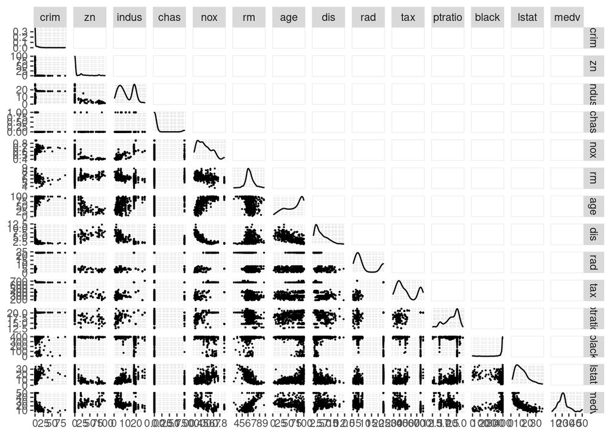

```r
GGally::ggpairs(boston,
                lower = list(continuous = wrap("points", size=0.1)),
                upper = list(continuous = wrap("cor", size=0)))
```

On the density plots on the plot diagonal, we see the distributions of the variables. Some of these are super skewed, resembling exponential or power-law distribution. Others look remotely or close to normal. Some seem to be double-peaked. The relationships between the variables are too numerous to describe in detail here, but we see many interesting patterns. Some resemble linear relationships but many don’t, casting doubt on using standard linear methods for these data.

## 4. Data transformation

Next, we’ll do z-transformation for each variable in the data, and save the resulting dataframe to a new object **boston_z**. Below is a brief summary of the standardized variables, with main value being infomation about quantile thresholds that describe the shapes of the distributions. In some variables these are very asymmetrical in relation to median, indicating great skewness already seen in density plots. Some max values are also ridiculously huge (like in **crim**) considering these are z-scaled variables. This means that the variable has at least one very influential observation.

```r
boston_z <- scale(boston)
boston_z <- as.data.frame(boston_z)
summary(boston_z)
```

```
##       crim                 zn               indus              chas
##  Min.   :-0.419367   Min.   :-0.48724   Min.   :-1.5563   Min.   :-0.2723
##  1st Qu.:-0.410563   1st Qu.:-0.48724   1st Qu.:-0.8668   1st Qu.:-0.2723
##  Median :-0.390280   Median :-0.48724   Median :-0.2109   Median :-0.2723
##  Mean   : 0.000000   Mean   : 0.00000   Mean   : 0.0000   Mean   : 0.0000
##  3rd Qu.: 0.007389   3rd Qu.: 0.04872   3rd Qu.: 1.0150   3rd Qu.:-0.2723
##  Max.   : 9.924110   Max.   : 3.80047   Max.   : 2.4202   Max.   : 3.6648
##       nox                rm               age               dis
##  Min.   :-1.4644   Min.   :-3.8764   Min.   :-2.3331   Min.   :-1.2658
##  1st Qu.:-0.9121   1st Qu.:-0.5681   1st Qu.:-0.8366   1st Qu.:-0.8049
##  Median :-0.1441   Median :-0.1084   Median : 0.3171   Median :-0.2790
##  Mean   : 0.0000   Mean   : 0.0000   Mean   : 0.0000   Mean   : 0.0000
##  3rd Qu.: 0.5981   3rd Qu.: 0.4823   3rd Qu.: 0.9059   3rd Qu.: 0.6617
##  Max.   : 2.7296   Max.   : 3.5515   Max.   : 1.1164   Max.   : 3.9566
##       rad               tax             ptratio            black
##  Min.   :-0.9819   Min.   :-1.3127   Min.   :-2.7047   Min.   :-3.9033
##  1st Qu.:-0.6373   1st Qu.:-0.7668   1st Qu.:-0.4876   1st Qu.: 0.2049
##  Median :-0.5225   Median :-0.4642   Median : 0.2746   Median : 0.3808
##  Mean   : 0.0000   Mean   : 0.0000   Mean   : 0.0000   Mean   : 0.0000
##  3rd Qu.: 1.6596   3rd Qu.: 1.5294   3rd Qu.: 0.8058   3rd Qu.: 0.4332
##  Max.   : 1.6596   Max.   : 1.7964   Max.   : 1.6372   Max.   : 0.4406
##      lstat              medv
##  Min.   :-1.5296   Min.   :-1.9063
##  1st Qu.:-0.7986   1st Qu.:-0.5989
##  Median :-0.1811   Median :-0.1449
##  Mean   : 0.0000   Mean   : 0.0000
##  3rd Qu.: 0.6024   3rd Qu.: 0.2683
##  Max.   : 3.5453   Max.   : 2.9865
```

Below, a categorical variable **crimeQ** is created by using quantiles as break-points.

```r
# Compute quantiles for variable crim
q <- quantile(boston_z$crim)

# Create new categorical variable for crime quantiles
# Drop the old crim variable
boston_z <- boston_z %>%
  mutate(crimeQ = case_when(crim < q[2] ~ 1,
                            crim >= q[2] & crim < q[3] ~ 2,
                            crim >= q[3] & crim < q[4] ~ 3,
                            crim >= q[4] ~ 4)) %>%
  dplyr::select(-crim)
```

Finally, divide the modified data into training data and test data.

```r
# N needed for training data
n_train <- round(0.8*dim(boston_z)[1])

# Index vector for training data
i_train <- sample(1:dim(boston)[1], n_train)

# Use the vector created above to split data into training and test data
boston_train <- boston_z[i_train,]
boston_test <- boston_z[-i_train,]
```

## 5.

Let’s computationally create the formula for discriminant analysis. It’s less tedious this way.

```r
predictors <- paste(names(boston_train[,-14]), collapse="+")
formula <- as.formula(paste("crimeQ", predictors, sep="~"))
print(formula)
```

```
## crimeQ ~ zn + indus + chas + nox + rm + age + dis + rad + tax +
##     ptratio + black + lstat + medv
```

Using this formula and the transformed data, let’s do linear discriminant analysis, where quantilized crime rate is predicted by all other variables. We know quantilized variables should have perfectly even 25/25/25/25 distribution, so let’s use these as priors in the model to account for any imperfections in randomization.

```r
res.lda <- MASS::lda(formula,
                     data=boston_train,
                     prior=c(0.25, 0.25, 0.25, 0.25))
```

Next, let’s draw a biplot, ggplot style.

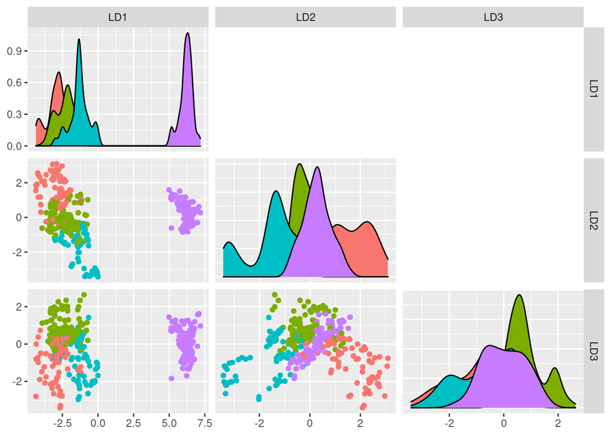

```r
# Predictions from LDA for training data
preds.lda <- predict(res.lda)

dat <- as.data.frame(cbind(preds.lda$class, preds.lda$x))
names(dat) <- c("class", "LD1", "LD2", "LD3")
dat$class <- as.factor(dat$class)

dat %>%
  ggpairs(columns = 2:4, aes(color=class), upper="blank")
```

## 6. Cross-validation

The real categorical variable **crimeQ** is removed from the test data, and saved as a separate object “correct”.

```r
# Make categorical crime variable a separate object
correct <- boston_test$crimeQ

# Remove the categorical crime variable from test data
boston_test <- boston_test %>%
  dplyr::select(-crimeQ)
```

Create predicted **crimeQ**-categories for the test data using the LDA model specified above. The predictions of this model are then cross-tabulated with real category values to assess the predictive accuracy of the model.

```r
preds <- predict(res.lda, newdata = boston_test)
prediction <- preds$class

tab <- table(prediction, correct)
tab
```

```
##           correct
## prediction  1  2  3  4
##          1 14  3  0  0
##          2 11 24 12  0
##          3  0  4 11  0
##          4  0  0  1 21
```

The correct predictions lie on the diagonal. We see that majority of the observations fall there, with several being just over or under diagonal. This means that the prediction errors are never completely opposite from the real value (for example category value 1 is predicted as 4 or vice versa). The prediction errors seem somewhat symmetrical regarding the category number, with rather similar number of “over- and underpredicted” observations.

By dividing the sum of numbers on the diagonal by the sum of all table values, we get the predictive accuracy of the model: the proportion of correctly predicted categories.

```r
sum(diag(tab)) / sum(tab)
```

```
## [1] 0.6930693
```

Considering that by guessing the accuracy would be around 25%, the model seems to do pretty good job with almost 70% accuracy.

## 7. K-means clustering

Euclidean distances for scaled Boston data

```r
boston_z <- scale(MASS::Boston)

dist_mat <- dist(boston_z, method="euclidean")
summary(dist_mat)
```

```
##    Min. 1st Qu.  Median    Mean 3rd Qu.    Max.
##  0.1343  3.4625  4.8241  4.9111  6.1863 14.3970
```

K-means clustering with 5 clusters.

```r
k.res <- kmeans(boston_z, centers = 5)
```

Evaluation of proper number of clusters

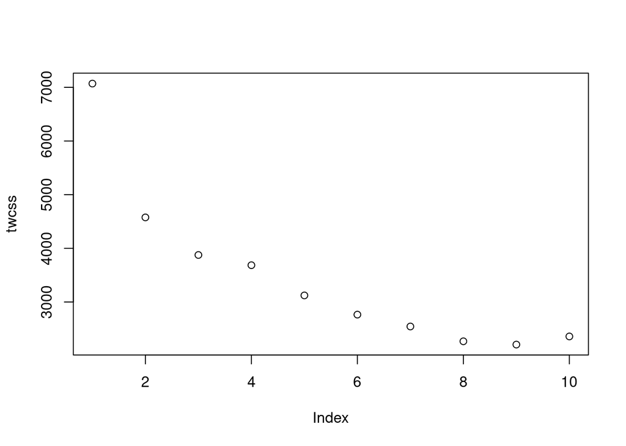

```r
k_max = 10

# Code from DataCamp
twcss <- sapply(1:k_max, function(k){kmeans(boston_z, k)$tot.withinss})
plot(twcss)
```

Greatest drop in total within category SS occurs at 2 clusters. This seems the appropriate number.

## Bonus

Below the data is first clustered with k-means with 5 clusters. Then LDA is fitted for the data using the created clusters as target categories. Created clusters and the categories predicted by LDA is presented in cross-tabulation below.

```r
# New k-means clustering with 5 clusters
k.res2 <- kmeans(boston_z, centers = 5)

predictors <- paste(names(as.data.frame(boston_z)), collapse="+")
formula <- as.formula(paste("k.res2cluster", predictors, sep="~"))

lda.res2 <- lda(k.res2$cluster ~ boston_z)
preds2 <- predict(lda.res2)$class

tab <- table(preds2, k.res2$cluster)
tab
```

```
##
## preds2   1   2   3   4   5
##      1  72   0   0   2   0
##      2   0  38   2   0   1
##      3   0   3 122   2   0
##      4   1   0   0  44   1
##      5  11   0   2   3 202
```

Most values fall on the diagonal, so prediction error seems to be very rare using this type of analysis. Finally the model accuracy (of LDA using kmeans as criterion) is calculated in same way as above.

```r
sum(diag(tab)) / sum(tab)
```

```
## [1] 0.944664
```

The model (LDA) has almost perfect accuracy predicting the categories created by k-means algorithm.